```python
import pandas as pd
import numpy as np
import matplotlib.pyplot as plt
import seaborn as sns

import warnings

warnings.filterwarnings('ignore')
```

# Metodología y datos

## Fuente y diseño de la base analítica

```python
datos_hogar = pd.read_csv('..//datos_originales/EPFhogar_2023.tab', sep='\t',
                           index_col=0)
datos_gastos = pd.read_csv('..//datos_originales/EPFgastos_2023.tab', sep='\t',
                           index_col=0)

rename_map = {
    'NUMERO': 'id',
    'FACTOR': 'factor',
    'CCAA': 'c_autonoma',
    'TAMAMU': 'tam_municipio',
    'UC1': 'tamano_ocde',
    'NMIEM5': 'n_menores',
    'NMIEM6': 'n_mayores',
    'NUMOCU': 'n_ocupados',
    'SEXOSP': 'hombre',
    'EDADSP': 'edad',
    'OCUSP': 'ocupado',
    'ESTUDIOSSP': 'estudios',
    'SECTOR': 'sector_publico',
    'IMPEXAC': 'ingresos_hogar',
    'REGTEN': 'alquiler',
    'NHABIT': 'n_habitaciones',
    'TIPHOGAR7': 'tipo_hogar'
}

cols_keep = [
    'id','factor','c_autonoma','tam_municipio',
    'tamano_ocde','n_menores','n_mayores','n_ocupados',
    'hombre','edad','ocupado','estudios','sector_publico',
    'ingresos_hogar','alquiler','n_habitaciones',
    'tipo_hogar'
]

datos_hogar = datos_hogar.rename(columns=rename_map)[cols_keep]
```

```python
print(datos_hogar.dtypes)
```

```
id                  int64
factor            float64
c_autonoma          int64
tam_municipio       int64
tamano_ocde       float64
n_menores           int64
n_mayores           int64
n_ocupados          int64
hombre              int64
edad                int64
ocupado             int64
estudios            int64
sector_publico    float64
ingresos_hogar      int64
alquiler            int64
n_habitaciones      int64
tipo_hogar          int64
dtype: object
```

**factor**

No tiene -9 y no hay que recodificarla.

```python
print(datos_hogar["factor"].isin([-9, np.nan]).any())
```

```
False
```

**c_autonoma**

No tiene -9, la pasamos a categórica con sus respectivas etiquetas.

```python
print(datos_hogar["c_autonoma"].isin([-9, np.nan]).any())
```

```
False
```

```python
labels_c_autonoma = {1: 'Andalucía', 2: 'Aragón', 3: 'Asturias', 4: 'Islas Baleares', 5: 'Canarias',
                     6: 'Cantabria', 7: 'Castilla y León', 8: 'Castilla-La Mancha', 9: 'Cataluña',
                     10: 'Comunidad Valenciana', 11: 'Extremadura', 12: 'Galicia', 13: 'Madrid',
                     14: 'Murcia', 15: 'Navarra', 16: 'País Vasco', 17: 'La Rioja',
                     18: 'Ceuta', 19: 'Melilla'}
datos_hogar['c_autonoma'] = datos_hogar['c_autonoma'].map(labels_c_autonoma).astype('category')
```

**tam_municipio**

No tiene -9, y la pasamos a categórica

```python
print(datos_hogar["tam_municipio"].isin([-9, np.nan]).any())
```

```
False
```

```python
# Municipios pequeños: Menosde 20,000 habitantes
# Municipios medianos: Entre 20,000 y 49,999 habitantes
# Municipios grandes: Entre 50,000 y 99,999 habitantes
# Municipios muy grandes: 100,000 o más habitantes

labels_tam_municipio = {1: 'Muy Grande', 2: 'Grande', 3: 'Mediano',
                        4: 'Pequeño', 5: 'Pequeño'}
datos_hogar['tam_municipio'] = datos_hogar['tam_municipio'].map(labels_tam_municipio).astype('category')
```

**tamano_ocde**

No tiene -9 y no necesita ser recodificada

```python
print(datos_hogar["tamano_ocde"].isin([-9, np.nan]).any())
```

```
False
```

**n_menores**

No tiene -9 y no necesita ser recodificada

```python
print(datos_hogar["n_menores"].isin([-9, np.nan]).any())
```

```
False
```

**n_mayores**

No tiene -9 y no necesita ser recodificada

```python
print(datos_hogar["n_mayores"].isin([-9, np.nan]).any())
```

```
False
```

**n_ocupados**

No tiene -9 y no necesita ser recodificada

```python
print(datos_hogar["n_ocupados"].isin([-9, np.nan]).any())
```

```
False
```

**hombre**

No tiene -9 y establecemos:

- **1** si el sustentador de la vivienda es un hombre, 0 en otro caso.
- **0** en otro caso.

```python
print(datos_hogar["hombre"].isin([-9, np.nan]).any())
```

```
False
```

```python
datos_hogar['hombre'] = np.where(datos_hogar['hombre'] == 1, 1, 0)
```

**edad**

No tiene -9 y pero necesita ser recodificada porque el 85 significa 85 o más

```python
print(datos_hogar["edad"].isin([-9, np.nan]).any())
```

```
False
```

```python
bins = [0, 30, 45, 65, 120]
labels = ['18-30', '31-45', '46-65', 'Más de 65']

datos_hogar['edad'] = pd.cut(datos_hogar['edad'], bins=bins, labels=labels, right=True)
```

**ocupado**

No tiene -9 y establecemos:

- **1** si el sustentador principal de la vivienda se encuentra ocupado (recibió salario por al menos 1 hora de trabajo la semana de referencia).
- **0** en otro caso.

```python
print(datos_hogar["ocupado"].isin([-9, np.nan]).any())
```

```
False
```

```python
datos_hogar['ocupado'] = np.where(datos_hogar['ocupado'] == 1, 1, 0)
```

**estudios**

No tiene -9 y la categorizamos

```python
print(datos_hogar["estudios"].isin([-9, np.nan]).any())
```

```
False
```

```python
labels_estudios = {1: 'Bajo', 2: 'Bajo', 3: 'Medio', 4: 'Medio', 5: 'Medio',
                    6: 'Alto', 7: 'Alto', 8: 'Alto'}
orden = ["Bajo", "Medio", "Alto"]
datos_hogar['estudios'] = pd.Categorical(datos_hogar['estudios'].map(labels_estudios).astype('category'), categories=orden,
                                         ordered=True)
```

**sector_publico**

Tenemos -9 y NAs, por lo que primero pasamos todos a -9. Como de esos -9 incluyen a "No aplica" y datos perdidos, lo que hacemos es codificar los que no están ocupados la semana de referencia significa que no trabajan en el sector público por lo que la incluimos esas observaciones como 0 y dejamos los NAs restantes, siguiendo el siguiente criterio:

- NA si sector_publico == -9
- 1 si el sustentador principal de la vivienda trabaja en el sector_publico
- 0 en otro caso

```python
print(datos_hogar["sector_publico"].isin([-9, np.nan]).any())
```

```
True
```

```python
datos_hogar['sector_publico'] = np.where(datos_hogar['sector_publico'].isna(), -9, np.where(datos_hogar['sector_publico'] == 6, 0, datos_hogar['sector_publico']))
print(f"Datos con sector_publico == -9 antes de la codificación: {sum(datos_hogar['sector_publico'] == -9)}")
datos_hogar['sector_publico'] = np.where(((datos_hogar['ocupado'] == 0)) & (datos_hogar['sector_publico'] == -9), 0, datos_hogar['sector_publico'])
datos_hogar['sector_publico'] = np.where(datos_hogar['sector_publico'] == -9, np.nan, datos_hogar['sector_publico'])
print(f"Datos con sector_publico == np.nan después de la codificación: {sum(datos_hogar['sector_publico'].isna())}")
```

```
Datos con sector_publico == -9 antes de la codificación: 3781
Datos con sector_publico == np.nan después de la codificación: 2019
```

**ingresos_hogar**

No tiene -9 y no necesita ser recodificada.

```python
print(datos_hogar["ingresos_hogar"].isin([-9, np.nan]).any())
```

```
False
```

**alquiler**

No tiene -9 y establecemos:

- 1 si la vivienda se encuentra en un estado de alquiler
- 0 en otro caso

```python
print(datos_hogar["alquiler"].isin([-9, np.nan]).any())
```

```
False
```

```python
datos_hogar['alquiler'] = np.where((datos_hogar['alquiler'] == 3) | (datos_hogar['alquiler'] == 4), 1, 0)
```

**n_habitaciones**

Tiene únicamente 2 -9, por lo que eliminamos esas 2 observaciones y no hace falta recodificarla.

```python
print(datos_hogar["n_habitaciones"].isin([-9, np.nan]).any())
```

```
True
```

```python
sum(datos_hogar['n_habitaciones'] == -9)
```

```
2
```

```python
datos_hogar['n_habitaciones'] = np.where(datos_hogar['n_habitaciones'] == -9, np.nan, datos_hogar['n_habitaciones'].astype(int))
```

**tipo_hogar**

No tiene -9 y categorizamos

```python
print(datos_hogar["tipo_hogar"].isin([-9, np.nan]).any())
```

```
False
```

```python
labels_tipo_hogar = {1: 'Persona sola <65', 2: 'Persona sola ≥65', 3: 'Pareja sin hijos', 4: 'Pareja con hijos',
                      5: 'Pareja con hijos', 6: 'Pareja con hijos', 7: 'Adulto con hijos', 8: 'Otros hogares'}
datos_hogar['tipo_hogar'] = datos_hogar['tipo_hogar'].map(labels_tipo_hogar).astype('category')
```

En gastos, tenemos un conjunto de datos con una observación por hogar y gasto específico, por lo que creamos una variable `grupo` que corresponde al grupo al que pertenece dicho gasto según https://www.ine.es/daco/daco42/daco4213/anexo_ecoicop.pdf:

- **01** = *Alimentos y bebidas no alcohólicas.*
- **02** = *Bebidas alcohólicas, tabaco y narcóticos.*
- **03** = *Artículos de vestir y calzado.*
- **04** = *Vivienda, agua, electricidad, gas y otros combustibles.*
- **05** = *Mobiliario, equipamiento del hogar y gastos corrientes de conservación de la vivienda.*
- **06** = *Salud.*
- **07** = *Transportes.*
- **08** = *Comunicaciones.*
- **09** = *Ocio, espectáculo y cultura.*
- **10** = *Enseñanza.*
- **11** = *Hoteles, cafés y restaurantes.*
- **12** = *Otros bienes y servicios.*

Una vez clasificado cada gasto en uno de los 12 grupos principales, lo que hacemos es una transformación del conjunto de datos, agrupando cada observación por vivienda, y creando 13 variables, 12 que corresponden a la proporción de gasto de cada vivienda en cada grupo y la última que corresponde al gasto monetario en € de cada vivienda en 2023.

```python
datos_gastos["grupo"] = datos_gastos["CODIGO"].astype(str).str[:2]

group_codes = [f"{i:02d}" for i in range(1,13)]
gastos_pivot = datos_gastos.groupby(['NUMERO','grupo'])['GASTO'].sum().unstack(fill_value=0)
gastos_pivot = gastos_pivot.reindex(columns=group_codes, fill_value=0)
gasto_total = gastos_pivot.sum(axis=1)
props = gastos_pivot.div(gasto_total.replace(0, np.nan), axis=0).fillna(0)

df_gastos = props.copy()
df_gastos['gasto_total'] = gasto_total
df_gastos.insert(0, 'id', df_gastos.index)

name_map = {
    '01':'alimentacion', '02':'alcohol_tabaco', '03':'ropa_calzado',
    '04':'vivienda', '05':'mobiliario', '06':'salud',
    '07':'transporte', '08':'comunicaciones', '09':'ocio_cultura',
    '10':'educacion', '11':'hoteles_restaurantes', '12':'bienes_servicios'
}
rename_map = {code: 'prop_' + name_map[code] for code in group_codes}
df_gastos = df_gastos.rename(columns=rename_map)

df_gastos = df_gastos.reset_index(drop=True)
datos_gastos_agg = df_gastos
```

```python
datos = datos_hogar.merge(datos_gastos_agg, on='id', how='inner')
datos.info()
```

```
<class 'pandas.DataFrame'>
RangeIndex: 20707 entries, 0 to 20706
Data columns (total 30 columns):
 #   Column                     Non-Null Count  Dtype
---  ------                     --------------  -----
 0   id                         20707 non-null  int64
 1   factor                     20707 non-null  float64
 2   c_autonoma                 20707 non-null  category
 3   tam_municipio              20707 non-null  category
 4   tamano_ocde                20707 non-null  float64
 5   n_menores                  20707 non-null  int64
 6   n_mayores                  20707 non-null  int64
 7   n_ocupados                 20707 non-null  int64
 8   hombre                     20707 non-null  int64
 9   edad                       20707 non-null  category
```

[output cut: 22 more lines]

## Tratamiento, depuración y construcción de la base analítica

```python
n_repetidos = (datos['id'].value_counts() > 1).sum()

print(f"Número de IDs repetidos: {n_repetidos}")

n_hogares_gasto_nulo = sum(datos['gasto_total'].isna() | (datos['gasto_total'] == 0))

print(f"Número de hogares con gasto total nulo o faltante: {n_hogares_gasto_nulo}")
```

```
Número de IDs repetidos: 0
Número de hogares con gasto total nulo o faltante: 0
```

```python
print("Número de valores nulos en 'n_habitaciones':", round(sum(datos['n_habitaciones'].isna()), 5))
print("Proporción de valores nulos en 'n_habitaciones':", round(sum(datos['n_habitaciones'].isna())/len(datos), 5))
datos = datos[~datos['n_habitaciones'].isna()]
print("Número de valores nulos en 'n_habitaciones' después de eliminarlos:", round(sum(datos['n_habitaciones'].isna()), 5))
print("Proporción de valores nulos en 'n_habitaciones' después de eliminarlos:", round(sum(datos['n_habitaciones'].isna())/len(datos), 5))
```

```
Número de valores nulos en 'n_habitaciones': 2
Proporción de valores nulos en 'n_habitaciones': 0.0001
Número de valores nulos en 'n_habitaciones' después de eliminarlos: 0
Proporción de valores nulos en 'n_habitaciones' después de eliminarlos: 0.0
```

```python
print("Número de valores nulos en 'sector_publico':", round(sum(datos['sector_publico'].isna()), 5))
print("Proporción de valores nulos en 'sector_publico':", round(sum(datos['sector_publico'].isna())/len(datos), 5))
```

```
Número de valores nulos en 'sector_publico': 2019
Proporción de valores nulos en 'sector_publico': 0.09751
```

## Análisis descriptivo y exploratorio

### Contexto económico del hogar

- **`factor`** (factor de elevación): peso muestral asignado por el INE a cada hogar encuestado. Indica cuántos hogares de la población representa. Se emplea para obtener estimaciones poblacionales; **en este EDA no se ponderan los estadísticos**, por lo que todos los resultados son descriptivos muestrales.
- **`gasto_total`** = gasto monetario anual (€) del hogar, **ya multiplicado** por el factor de elevación en la fuente original.
- **`gasto_total_crudo`** = $\frac{\text{gasto\_total}}{\text{factor}}$, es decir, el gasto anual *muestral* (sin ponderar) del hogar en euros corrientes de 2023.
- **`ingresos_hogar`** = ingresos netos mensuales del hogar declarados en la encuesta.

```python
datos['gasto_total_crudo'] = datos['gasto_total'] / datos['factor']
datos['log_gasto_total_crudo'] = np.log1p(datos['gasto_total_crudo'])
datos['log_ingresos_hogar'] = np.log1p(datos['ingresos_hogar'])

variables_mon = ['gasto_total_crudo', 'ingresos_hogar']

summary_rows = []
for v in variables_mon:
    s = datos[v]
    row = {
        'Variable': v,
        'Media': round(s.mean(), 2),
        'DE': round(s.std(), 2),
        'Min': round(s.min(), 2),
        'P25': round(s.quantile(0.25), 2),
        'Mediana': round(s.median(), 2),
        'P75': round(s.quantile(0.75), 2),
        'Max': round(s.max(), 2)
    }
    summary_rows.append(row)

tabla_monetaria = pd.DataFrame(summary_rows)

display(tabla_monetaria)
```

|  | Variable | Media | DE | Min | P25 | Mediana | P75 | Max |
| --- | --- | --- | --- | --- | --- | --- | --- | --- |
| 0 | gasto_total_crudo | 33329.55 | 19458.52 | 1106.78 | 19484.61 | 28964.36 | 42196.47 | 272006.1 |
| 1 | ingresos_hogar | 2514.83 | 1534.22 | 0.00 | 1390.00 | 2244.00 | 3218.00 | 36400.0 |

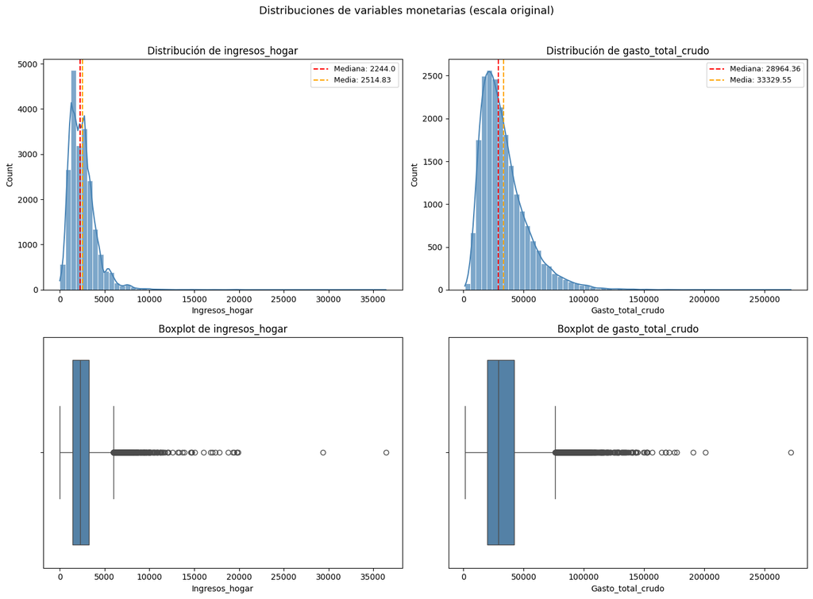

```python
variables = ["ingresos_hogar", "gasto_total_crudo"]
fig, axes = plt.subplots(2, 2, figsize=(14, 10))

for i, var in enumerate(variables):
    s = datos[var]
    ax_hist = axes[0, i]
    sns.histplot(s, bins=60, kde=True, color='steelblue', edgecolor='white', alpha=0.7, ax=ax_hist)
    ax_hist.axvline(s.median(), color='red', ls='--', lw=1.5, label=f'Mediana: {round(s.median(), 2)}')
    ax_hist.axvline(s.mean(), color='orange', ls='--', lw=1.5, label=f'Media: {round(s.mean(), 2)}')

    ax_hist.set_title(f'Distribución de {var}')
    ax_hist.set_xlabel(var.capitalize())
    ax_hist.legend(fontsize=9)

    ax_box = axes[1, i]
    sns.boxplot(x=s, color='steelblue', ax=ax_box)
    ax_box.set_xlabel(var.capitalize())
    ax_box.set_title(f'Boxplot de {var}')

plt.suptitle('Distribuciones de variables monetarias (escala original)', fontsize=13, y=1.02)
plt.tight_layout()
plt.show()
```

[figure not shown]

```python
variables = ["log_ingresos_hogar", "log_gasto_total_crudo"]
fig, axes = plt.subplots(2, 2, figsize=(14, 10))

for i, var in enumerate(variables):
    s = datos[var]
    ax_hist = axes[0, i]
    sns.histplot(s, bins=60, kde=True, color='steelblue', edgecolor='white', alpha=0.7, ax=ax_hist)
    ax_hist.axvline(s.median(), color='red', ls='--', lw=1.5, label=f'Mediana: {round(s.median(), 2)}')
    ax_hist.axvline(s.mean(), color='orange', ls='--', lw=1.5, label=f'Media: {round(s.mean(), 2)}')
    ax_hist.set_title(f'Distribución de {var}')
    ax_hist.set_xlabel(var.capitalize())
    ax_hist.legend(fontsize=9)
    ax_box = axes[1, i]
    sns.boxplot(x=s, color='steelblue', ax=ax_box)
    ax_box.set_xlabel(var.capitalize())
    ax_box.set_title(f'Boxplot de {var}')

plt.suptitle('Distribuciones de variables monetarias (escala original)', fontsize=13, y=1.02)
plt.tight_layout()
plt.show()
```

### Distribución univariante de las proporciones de gasto

```python
proporciones = [col for col in datos.columns if col.startswith('prop_')]
rows_p = []
for p in proporciones:
    s = datos[p]
    rows_p.append({
        'Variable': p.replace('prop_', ''),
        '% hogares con gasto 0': round((s == 0).mean() * 100, 1),
        'Media': round(s.mean(), 4),
        'Mediana': round(s.median(), 4),
        'IQR': round(s.quantile(0.75) - s.quantile(0.25), 4)
    })

tabla_props = pd.DataFrame(rows_p)

display(tabla_props)
```

|  | Variable | % hogares con gasto 0 | Media | Mediana | IQR |
| --- | --- | --- | --- | --- | --- |
| 0 | alimentacion | 2.7 | 0.1784 | 0.1653 | 0.1430 |
| 1 | alcohol_tabaco | 43.4 | 0.0148 | 0.0023 | 0.0147 |
| 2 | ropa_calzado | 26.7 | 0.0384 | 0.0231 | 0.0572 |
| 3 | vivienda | 0.0 | 0.3563 | 0.3310 | 0.2148 |
| 4 | mobiliario | 8.6 | 0.0381 | 0.0231 | 0.0410 |
| 5 | salud | 29.6 | 0.0360 | 0.0125 | 0.0448 |
| 6 | transporte | 15.4 | 0.0930 | 0.0532 | 0.1336 |
| 7 | comunicaciones | 3.0 | 0.0309 | 0.0261 | 0.0231 |
| 8 | ocio_cultura | 24.0 | 0.0438 | 0.0211 | 0.0590 |
| 9 | educacion | 74.2 | 0.0101 | 0.0000 | 0.0003 |
| 10 | hoteles_restaurantes | 23.4 | 0.0863 | 0.0555 | 0.1256 |
| 11 | bienes_servicios | 1.1 | 0.0738 | 0.0612 | 0.0517 |

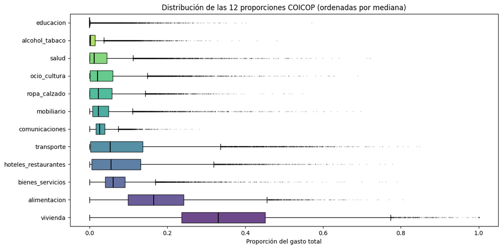

```python
medians_order = datos[proporciones].median().sort_values(ascending=False)
ordered_props = medians_order.index.tolist()
labels_short = [p.replace('prop_', '') for p in ordered_props]

fig, ax = plt.subplots(figsize=(12, 6))
bp = ax.boxplot(
    [datos[p].dropna() for p in ordered_props],
    vert=False, patch_artist=True, widths=0.6,
    flierprops=dict(marker='.', markersize=2, alpha=0.15, color='gray'),
    medianprops=dict(color='black', linewidth=1.5)
)
colors = sns.color_palette("viridis", len(ordered_props))
for patch, color in zip(bp['boxes'], colors):
    patch.set_facecolor(color)
    patch.set_alpha(0.8)

ax.set_yticks(range(1, len(labels_short)+1))
ax.set_yticklabels(labels_short)
ax.set_xlabel('Proporción del gasto total')
ax.set_title(f'Distribución de las 12 proporciones COICOP (ordenadas por mediana)')
plt.tight_layout()
plt.show()
```

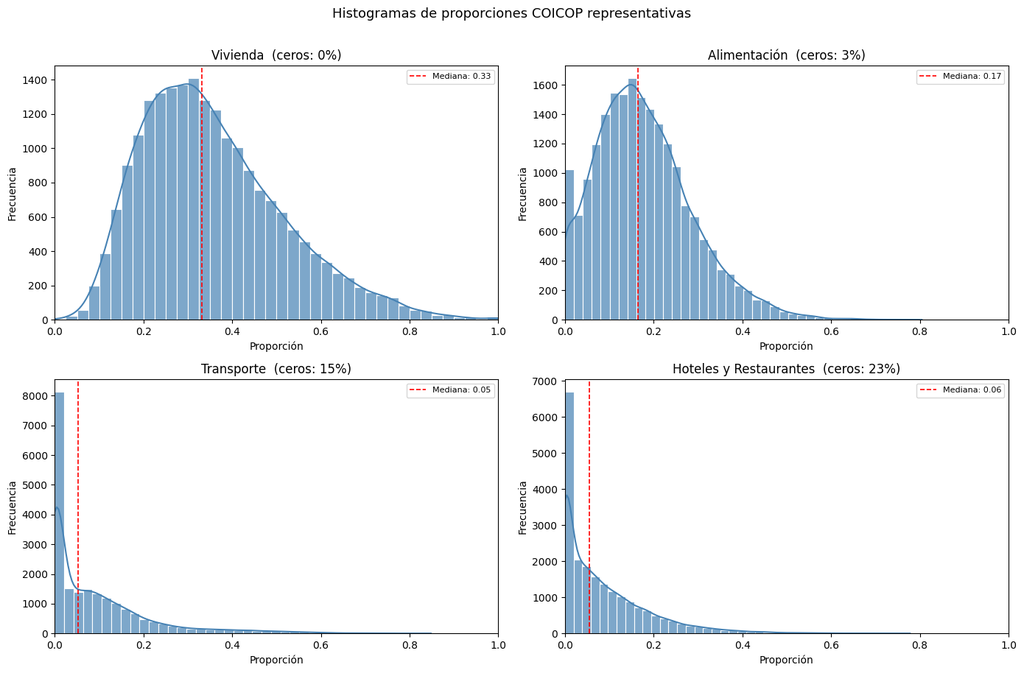

```python
cols_hist = ['prop_vivienda', 'prop_alimentacion', 'prop_transporte', 'prop_hoteles_restaurantes']
titles_hist = ['Vivienda', 'Alimentación', 'Transporte', 'Hoteles y Restaurantes']

fig, axes = plt.subplots(2, 2, figsize=(14, 9))
for ax, col, title in zip(axes.ravel(), cols_hist, titles_hist):
    s = datos[col]
    sns.histplot(s, bins=40, kde=True, ax=ax, color='steelblue', edgecolor='white', alpha=0.7)
    ax.set_xlim(0, 1)
    ax.set_xlabel('Proporción')
    ax.set_ylabel('Frecuencia')
    pct_zero = (s == 0).mean() * 100
    skew = s.skew()
    ax.set_title(f'{title}  (ceros: {pct_zero:.0f}%)')
    ax.axvline(s.median(), color='red', ls='--', lw=1.2, label=f'Mediana: {round(s.median(), 2)}')
    ax.legend(fontsize=8)

plt.suptitle(f'Histogramas de proporciones COICOP representativas', fontsize=13, y=1.01)
plt.tight_layout()
plt.show()
```

### Naturaleza composicional del presupuesto

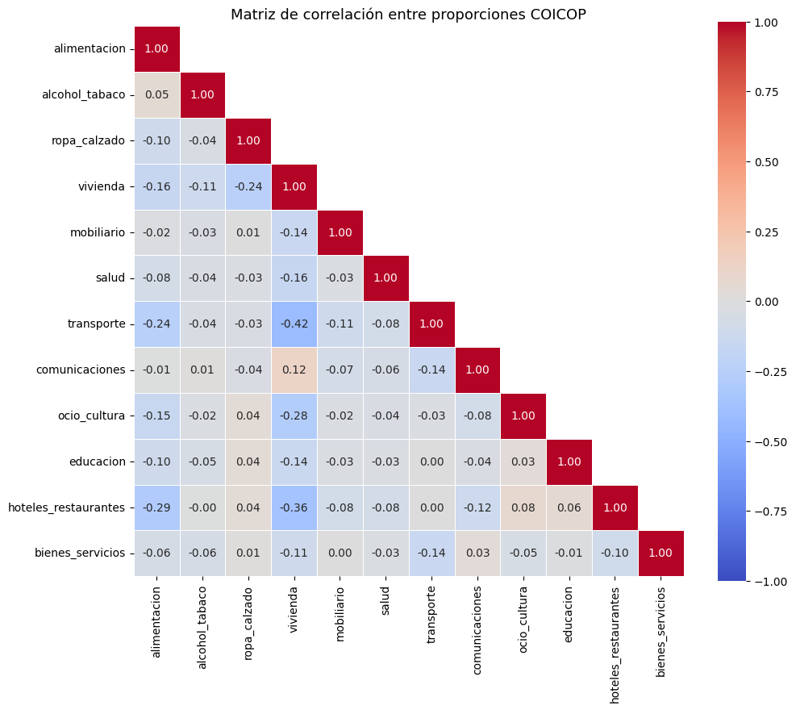

```python
corr_matrix = datos[proporciones].corr()
labels_c = [p.replace('prop_', '') for p in proporciones]

fig, ax = plt.subplots(figsize=(11, 9))
mask = np.triu(np.ones_like(corr_matrix, dtype=bool), k=1)
sns.heatmap(corr_matrix, annot=True, fmt=".2f", cmap="coolwarm", vmin=-1, vmax=1,
            xticklabels=labels_c, yticklabels=labels_c, mask=mask, ax=ax,
            linewidths=0.5, square=True)
ax.set_title(f'Matriz de correlación entre proporciones COICOP', fontsize=13)
```

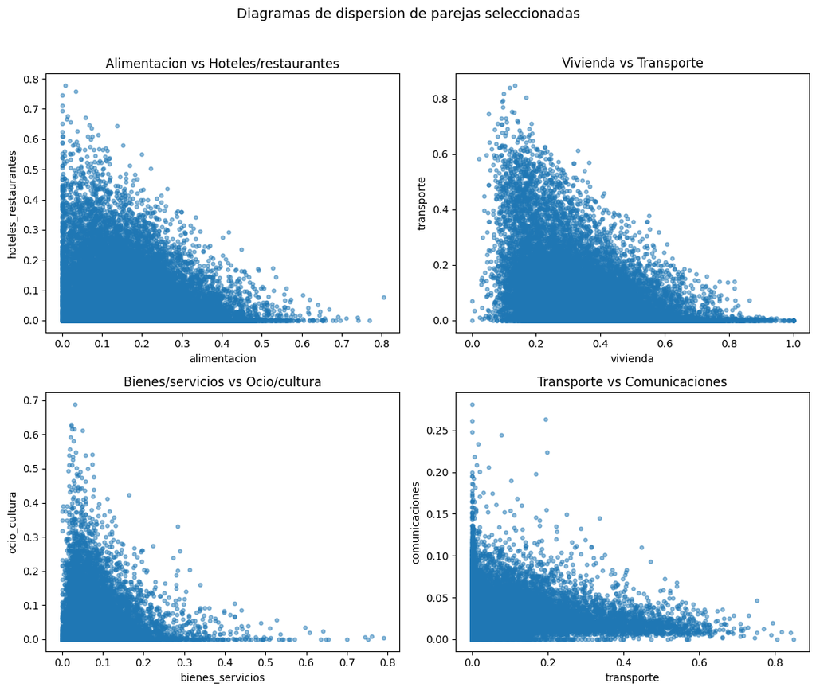

```python
pairs = [
    ('prop_alimentacion', 'prop_hoteles_restaurantes', 'Alimentacion vs Hoteles/restaurantes'),
    ('prop_vivienda', 'prop_transporte', 'Vivienda vs Transporte'),
    ('prop_bienes_servicios', 'prop_ocio_cultura', 'Bienes/servicios vs Ocio/cultura'),
    ('prop_transporte', 'prop_comunicaciones', 'Transporte vs Comunicaciones'),
]

fig, axes = plt.subplots(2, 2, figsize=(11, 9))
axes = axes.ravel()
for i, (x, y, title) in enumerate(pairs):
    ax = axes[i]
    ax.scatter(datos[x], datos[y], s=12, alpha=0.5)
    ax.set_xlabel(x.replace('prop_', ''))
    ax.set_ylabel(y.replace('prop_', ''))
    ax.set_title(title)

plt.suptitle('Diagramas de dispersion de parejas seleccionadas', fontsize=13, y=1.02)
plt.tight_layout()
plt.show()
```

### Descripción de las variables sociodemográficas

```python
cont_vars = ['tamano_ocde', 'n_menores', 'n_mayores', 'n_ocupados', 'n_habitaciones']
rows_c = []
for v in cont_vars:
    s = datos[v].dropna()
    rows_c.append({
        'Variable': v,
        'Media': round(s.mean(), 2),
        'Desviacion': round(s.std(), 2),
        'Min': round(s.min(), 2),
        'P25': round(s.quantile(0.25), 2),
        'Mediana': round(s.median(), 2),
        'p75': round(s.quantile(0.75), 2),
        'Max': round(s.max(), 2),
    })

tabla_numerica = pd.DataFrame(rows_c)
display(tabla_numerica)
```

|  | Variable | Media | Desviacion | Min | P25 | Mediana | p75 | Max |
| --- | --- | --- | --- | --- | --- | --- | --- | --- |
| 0 | tamano_ocde | 1.99 | 0.78 | 1.0 | 1.7 | 1.7 | 2.4 | 7.6 |
| 1 | n_menores | 0.44 | 0.79 | 0.0 | 0.0 | 0.0 | 1.0 | 8.0 |
| 2 | n_mayores | 2.06 | 0.89 | 1.0 | 1.0 | 2.0 | 2.0 | 9.0 |
| 3 | n_ocupados | 1.08 | 0.91 | 0.0 | 0.0 | 1.0 | 2.0 | 6.0 |
| 4 | n_habitaciones | 5.07 | 1.18 | 1.0 | 4.0 | 5.0 | 6.0 | 8.0 |

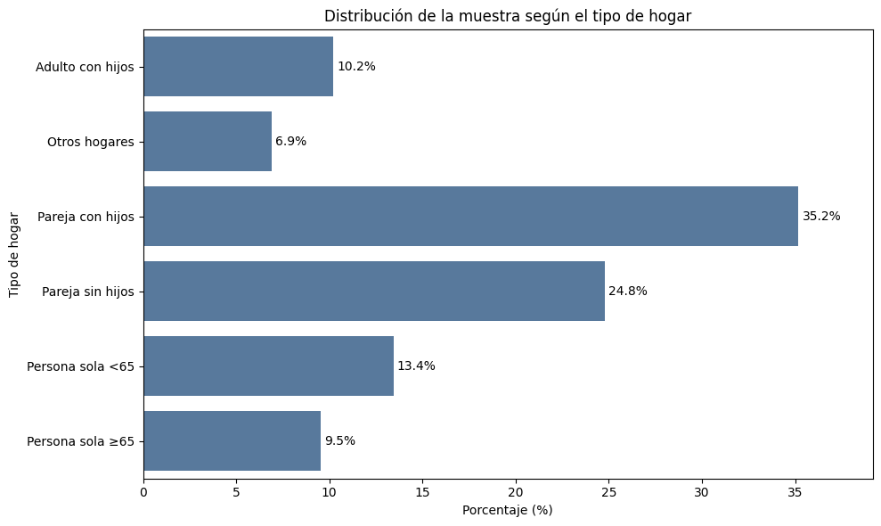

```python
fig, ax = plt.subplots(figsize=(10, 6))

color_hogar = "#4C78A8"

p1 = datos["tipo_hogar"].dropna().value_counts(normalize=True).mul(100)

sns.barplot(x=p1.values, y=p1.index, ax=ax, color=color_hogar)
ax.set_title("Distribución de la muestra según el tipo de hogar")
ax.set_xlabel("Porcentaje (%)")
ax.set_ylabel("Tipo de hogar")
ax.set_xlim(0, p1.max() + 4)

for barra in ax.patches:
    ancho = barra.get_width()
    y = barra.get_y() + barra.get_height() / 2
    ax.text(ancho + 0.2, y, f"{ancho:.1f}%", va="center", ha="left")

plt.tight_layout()
plt.show()
```

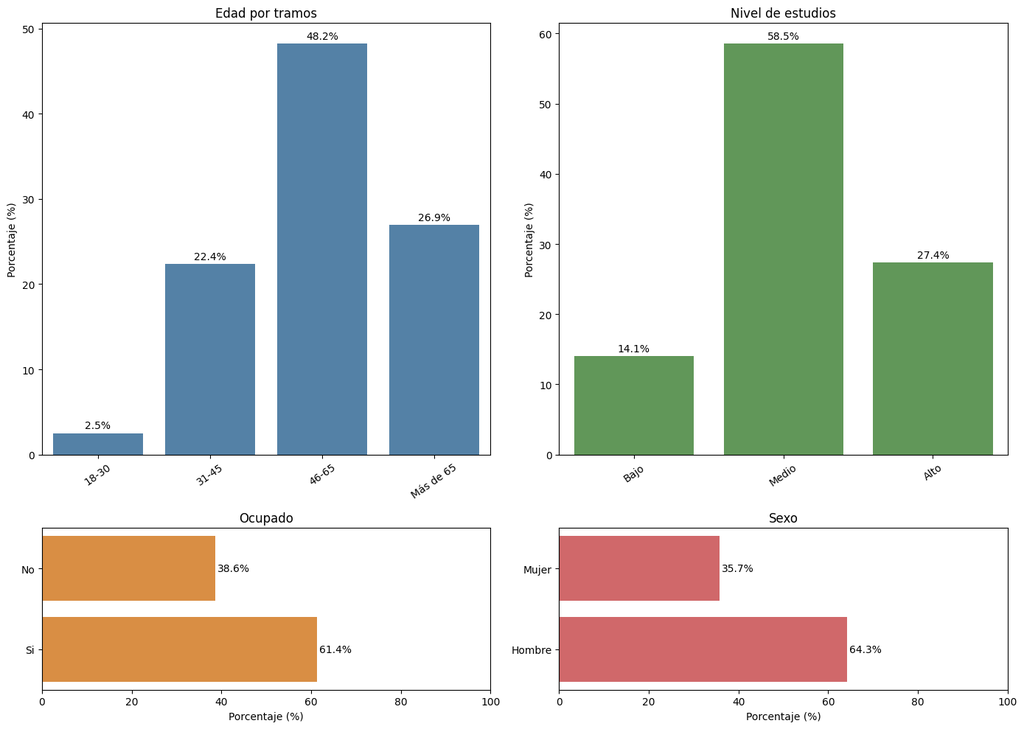

```python
fig, ax = plt.subplots(2, 2, figsize=(14, 10), gridspec_kw={"height_ratios": [2, 0.75]})

color_edad = "steelblue"
color_estudios = "#59A14F"
color_ocupado = "#F28E2B"
color_hombre = "#E15759"

orden_edad = (
    list(datos["edad"].cat.categories)
    if pd.api.types.is_categorical_dtype(datos["edad"])
    else list(datos["edad"].dropna().unique())
)
p_edad = datos["edad"].dropna().value_counts(normalize=True).mul(100).reindex(orden_edad)

sns.barplot(x=p_edad.index, y=p_edad.values, ax=ax[0, 0], color=color_edad)
ax[0, 0].set_title("Edad por tramos")
ax[0, 0].set_xlabel("")
ax[0, 0].set_ylabel("Porcentaje (%)")
ax[0, 0].tick_params(axis="x", rotation=35)
for barra in ax[0, 0].patches:
    alto = barra.get_height()
    x = barra.get_x() + barra.get_width() / 2
    ax[0, 0].text(x, alto + 0.3, f"{alto:.1f}%", ha="center", va="bottom")

orden_estudios = (
    list(datos["estudios"].cat.categories)
    if pd.api.types.is_categorical_dtype(datos["estudios"])
    else list(datos["estudios"].dropna().unique())
)
p_estudios = datos["estudios"].dropna().value_counts(normalize=True).mul(100).reindex(orden_estudios)

sns.barplot(x=p_estudios.index, y=p_estudios.values, ax=ax[0, 1], color=color_estudios)
ax[0, 1].set_title("Nivel de estudios")
ax[0, 1].set_xlabel("")
ax[0, 1].set_ylabel("Porcentaje (%)")
ax[0, 1].tick_params(axis="x", rotation=35)
for barra in ax[0, 1].patches:
    alto = barra.get_height()
    x = barra.get_x() + barra.get_width() / 2
    ax[0, 1].text(x, alto + 0.3, f"{alto:.1f}%", ha="center", va="bottom")

p_ocupado = datos["ocupado"].dropna().value_counts(normalize=True).mul(100).sort_index()
p_ocupado.index = p_ocupado.index.map({0: "No", 1: "Si"})

sns.barplot(x=p_ocupado.values, y=p_ocupado.index, ax=ax[1, 0], color=color_ocupado)
ax[1, 0].set_title("Ocupado")
ax[1, 0].set_xlabel("Porcentaje (%)")
ax[1, 0].set_ylabel("")
ax[1, 0].set_xlim(0, 100)
for barra in ax[1, 0].patches:
    ancho = barra.get_width()
    y = barra.get_y() + barra.get_height() / 2
    ax[1, 0].text(ancho + 0.5, y, f"{ancho:.1f}%", va="center", ha="left")

p_hombre = datos["hombre"].dropna().value_counts(normalize=True).mul(100).sort_index()
p_hombre.index = p_hombre.index.map({0: "Mujer", 1: "Hombre"})

sns.barplot(x=p_hombre.values, y=p_hombre.index, ax=ax[1, 1], color=color_hombre)
ax[1, 1].set_title("Sexo")
ax[1, 1].set_xlabel("Porcentaje (%)")
ax[1, 1].set_ylabel("")
ax[1, 1].set_xlim(0, 100)
for barra in ax[1, 1].patches:
    ancho = barra.get_width()
    y = barra.get_y() + barra.get_height() / 2
    ax[1, 1].text(ancho + 0.5, y, f"{ancho:.1f}%", va="center", ha="left")

plt.tight_layout()
plt.show()
```

### Cruces exploratorios

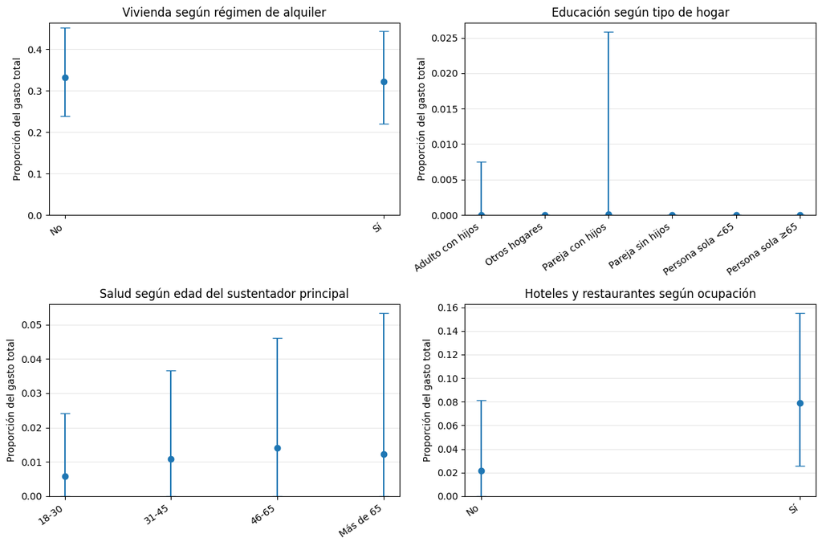

```python
data = datos.copy()

data["alquiler_label"] = data["alquiler"].map({0: "No", 1: "Sí"})
data["ocupado_label"] = data["ocupado"].map({0: "No", 1: "Sí"})

def plot_mediana_iqr(ax, y, grupo, titulo, xlabel=""):
    resumen = (
        data[[y, grupo]]
        .dropna()
        .groupby(grupo)[y]
        .agg(
            q1=lambda x: x.quantile(0.25),
            mediana="median",
            q3=lambda x: x.quantile(0.75)
        )
        .reset_index()
    )

    x = range(len(resumen))

    ax.errorbar(
        x,
        resumen["mediana"],
        yerr=[
            resumen["mediana"] - resumen["q1"],
            resumen["q3"] - resumen["mediana"]
        ],
        fmt="o",
        capsize=5
    )

    ax.set_xticks(x)
    ax.set_xticklabels(resumen[grupo], rotation=35, ha="right")
    ax.set_title(titulo)
    ax.set_ylabel("Proporción del gasto total")
    ax.set_xlabel(xlabel)
    ax.set_ylim(bottom=0)
    ax.grid(axis="y", alpha=0.3)

fig, axes = plt.subplots(2, 2, figsize=(12, 8))

plot_mediana_iqr(
    axes[0, 0],
    y="prop_vivienda",
    grupo="alquiler_label",
    titulo="Vivienda según régimen de alquiler"
)

plot_mediana_iqr(
    axes[0, 1],
    y="prop_educacion",
    grupo="tipo_hogar",
    titulo="Educación según tipo de hogar"
)

plot_mediana_iqr(
    axes[1, 0],
    y="prop_salud",
    grupo="edad",
    titulo="Salud según edad del sustentador principal"
)

plot_mediana_iqr(
    axes[1, 1],
    y="prop_hoteles_restaurantes",
    grupo="ocupado_label",
    titulo="Hoteles y restaurantes según ocupación"
)

plt.tight_layout()
plt.show()
```

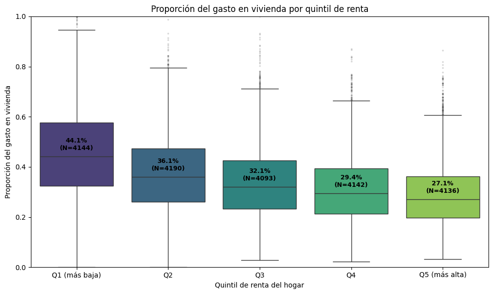

```
Proporción de gasto en vivienda por quintil de renta
```

| quintil_renta | N | Media | Mediana | IQR |
| --- | --- | --- | --- | --- |
| Q1 (más baja) | 4144 | 0.4571 | 0.4409 | 0.2523 |
| Q2 | 4190 | 0.3769 | 0.3607 | 0.2139 |
| Q3 | 4093 | 0.3412 | 0.3207 | 0.1918 |
| Q4 | 4142 | 0.3141 | 0.2939 | 0.1807 |
| Q5 (más alta) | 4136 | 0.2918 | 0.2711 | 0.1645 |

```python
datos['quintil_renta'] = pd.qcut(datos['ingresos_hogar'], q=5,
                                  labels=['Q1 (más baja)', 'Q2', 'Q3', 'Q4', 'Q5 (más alta)'])


fig, ax = plt.subplots(figsize=(10, 6))
sns.boxplot(x='quintil_renta', y='prop_vivienda', data=datos, palette='viridis', ax=ax,
            flierprops=dict(marker='.', markersize=3, alpha=0.2))

medians = datos.groupby('quintil_renta', observed=True)['prop_vivienda'].median()
ns = datos.groupby('quintil_renta', observed=True).size()
for i, (med, n) in enumerate(zip(medians, ns)):
    ax.text(i, med + 0.02, f'{med:.1%}\n(N={n})', ha='center', va='bottom', fontweight='bold', fontsize=9)

ax.set_xlabel('Quintil de renta del hogar')
ax.set_ylabel('Proporción del gasto en vivienda')
ax.set_title(f'Proporción del gasto en vivienda por quintil de renta')
ax.set_ylim(0, 1)
plt.tight_layout()
plt.show()

tabla_q = datos.groupby('quintil_renta', observed=True)['prop_vivienda'].agg(
    N='count', Media=lambda x: round(x.mean(), 4), Mediana='median',
    IQR=lambda x: round(x.quantile(0.75) - x.quantile(0.25), 4)
).round(4)

del(datos['quintil_renta'])
print("Proporción de gasto en vivienda por quintil de renta")
display(tabla_q)
```

```python
datos.to_csv('..//datos_procesados/datos_iniciales.csv', index=False)
```